# Exploratory Data Analysis: Analyzing California Wildfires from 2000-2023

#### Data Source: California Open Data Portal

#### https://gis.data.cnra.ca.gov/maps/CALFIRE-Forestry::california-fire-perimeters-all-1

###### The purpose of this notebook is to explore methods of exploratory data analysis utilizing popular data analysis libraries such as pandas, matplotlib, and seaborn. The main questions we'd like to explore in this dataset are:

- What have been the general trend for California wildfires over the last 23 years? Overall, do wildfires in California seem to be getting better or worse over time?
- What kind of extreme outlier events have occured in the past 23 years?
- What are the main causes of wildfires? Have these changed over time?

## Part 1: Data Cleaning

```python
# Import Libraries

import pandas as pd
import numpy as np
import seaborn as sea
import missingno as msno
import matplotlib.pyplot as plt
import datetime
```

```python
#read in csv

df = pd.read_csv(r'C:\Users\User\OneDrive\Desktop\Gis data\Python Data\CA_wildfires3.csv')
df
```

|  | OBJECTID | Year | State | Agency | Unit ID | Fire Name | Local Incident Number | Alarm Date | Containment Date | Cause | ... | GIS Calculated Acres | Comments | Complex Name | IRWIN ID | Fire Number (historical use) | Complex ID | DECADES | Shape__Area | Shape__Length | Source |
| --- | --- | --- | --- | --- | --- | --- | --- | --- | --- | --- | --- | --- | --- | --- | --- | --- | --- | --- | --- | --- | --- |
| 0 | 1 | 2023 | CA | CDF | SKU | WHITWORTH | 00004808 | 6/17/2023 | 6/17/2023 | 5.0 | ... | 5.729125 | NaN | NaN | {7985848C-0AC2-4BA4-8F0E-29F778652E61} | NaN | NaN | 2020 | 4.140784e+04 | 1247.166034 | CA Fire Permiters, CA Open Data Portal |
| 1 | 2 | 2023 | CA | LRA | BTU | KAISER | 00010225 | 6/2/2023 | 6/2/2023 | 5.0 | ... | 13.602380 | NaN | NaN | {43EBCC88-B3AC-48EB-8EF5-417FE0939CCF} | NaN | NaN | 2020 | 9.345588e+04 | 1285.514550 | CA Fire Permiters, CA Open Data Portal |
| 2 | 3 | 2023 | CA | CDF | AEU | JACKSON | 00017640 | 7/1/2023 | 7/2/2023 | 2.0 | ... | 27.814460 | NaN | NaN | {B64E1355-BF1D-441A-95D0-BC1FBB93483B} | NaN | NaN | 2020 | 1.830285e+05 | 2697.587429 | CA Fire Permiters, CA Open Data Portal |
| 3 | 4 | 2023 | CA | CDF | AEU | CARBON | 00018821 | 7/11/2023 | 7/11/2023 | 9.0 | ... | 58.760230 | NaN | NaN | {CB41DB0A-E4B1-489D-A4EA-738F2CD6DB3B} | NaN | NaN | 2020 | 3.882220e+05 | 2548.738779 | CA Fire Permiters, CA Open Data Portal |
| 4 | 5 | 2023 | CA | CDF | AEU | LIBERTY | 00018876 | 7/11/2023 | 7/12/2023 | 14.0 | ... | 70.979000 | NaN | NaN | {F83F70A4-07A7-40B8-BD51-10CCC1C30D63} | NaN | NaN | 2020 | 4.664560e+05 | 5106.936526 | CA Fire Permiters, CA Open Data Portal |
| ... | ... | ... | ... | ... | ... | ... | ... | ... | ... | ... | ... | ... | ... | ... | ... | ... | ... | ... | ... | ... | ... |
| 7812 | 7813 | 2000 | CA | NPS | GNP | PT BONITA | 00000035 | 10/22/2000 | 11/1/2000 | 8.0 | ... | 11.038910 | NaN | NaN | NaN | 00000035 | NaN | 2000 | 7.171864e+04 | 1224.646739 | CA Fire Permiters, CA Open Data Portal |
| 7813 | 7814 | 2000 | CA | NPS | KNP | CONIFER | 00000000 | 1/1/2000 | 1/20/2000 | 18.0 | ... | 4.834736 | NaN | NaN | NaN | 00000003 | NaN | 2000 | 3.029859e+04 | 723.541643 | CA Fire Permiters, CA Open Data Portal |
| 7814 | 7815 | 2000 | CA | NPS | DVP | HAPPY | 00204331 | 7/22/2000 | 8/5/2000 | 5.0 | ... | 4907.750000 | NaN | NaN | NaN | 0004 | NaN | 2000 | 3.045575e+07 | 32254.675480 | CA Fire Permiters, CA Open Data Portal |
| 7815 | 7816 | 2000 | CA | CCO | LAC | CALABASAS | 00001008 | 6/11/2000 | 6/12/2000 | 14.0 | ... | 1024.243000 | NaN | NaN | NaN | 00045000 | NaN | 2000 | 6.072928e+06 | 12488.245860 | CA Fire Permiters, CA Open Data Portal |
| 7816 | 7817 | 2000 | NV | BLM | CCD | TURTLE MOUNTAIN | J906 | NaN | NaN | 14.0 | ... | 1075.476000 | NaN | RENO COMPLEX | NaN | NaN | NaN | 2000 | 7.447800e+06 | 15250.545150 | CA Fire Permiters, CA Open Data Portal |

7817 rows × 22 columns

```python
# see snapshot of columns and their respective data types
df.info()
```

```
<class 'pandas.core.frame.DataFrame'>
RangeIndex: 7817 entries, 0 to 7816
Data columns (total 22 columns):
 #   Column                        Non-Null Count  Dtype
---  ------                        --------------  -----
 0   OBJECTID                      7817 non-null   int64
 1   Year                          7817 non-null   int64
 2   State                         7817 non-null   object
 3   Agency                        7812 non-null   object
 4   Unit ID                       7799 non-null   object
 5   Fire Name                     7799 non-null   object
 6   Local Incident Number         7453 non-null   object
 7   Alarm Date                    7764 non-null   object
 8   Containment Date              7412 non-null   object
 9   Cause                         7808 non-null   float64
 10  Collection Method             7514 non-null   float64
 11  Management Objective          7666 non-null   float64
 12  GIS Calculated Acres          7817 non-null   float64
 13  Comments                      2565 non-null   object
 14  Complex Name                  591 non-null    object
 15  IRWIN ID                      2696 non-null   object
 16  Fire Number (historical use)  2976 non-null   object
 17  Complex ID                    359 non-null    object
 18  DECADES                       7817 non-null   int64
 19  Shape__Area                   7817 non-null   float64
 20  Shape__Length                 7817 non-null   float64
 21  Source                        7817 non-null   object
dtypes: float64(6), int64(3), object(13)
memory usage: 1.3+ MB
```

```python
#create a subset of the original table with only relevant columns we want to look at
fires = df[['Year', 'State', 'Fire Name', 'Alarm Date', 'Containment Date', 'Cause', 'GIS Calculated Acres', 'Complex Name', 'Shape__Area', 'Shape__Length']]
fires
```

|  | Year | State | Fire Name | Alarm Date | Containment Date | Cause | GIS Calculated Acres | Complex Name | Shape__Area | Shape__Length |
| --- | --- | --- | --- | --- | --- | --- | --- | --- | --- | --- |
| 0 | 2023 | CA | WHITWORTH | 6/17/2023 | 6/17/2023 | 5.0 | 5.729125 | NaN | 4.140784e+04 | 1247.166034 |
| 1 | 2023 | CA | KAISER | 6/2/2023 | 6/2/2023 | 5.0 | 13.602380 | NaN | 9.345588e+04 | 1285.514550 |
| 2 | 2023 | CA | JACKSON | 7/1/2023 | 7/2/2023 | 2.0 | 27.814460 | NaN | 1.830285e+05 | 2697.587429 |
| 3 | 2023 | CA | CARBON | 7/11/2023 | 7/11/2023 | 9.0 | 58.760230 | NaN | 3.882220e+05 | 2548.738779 |
| 4 | 2023 | CA | LIBERTY | 7/11/2023 | 7/12/2023 | 14.0 | 70.979000 | NaN | 4.664560e+05 | 5106.936526 |
| ... | ... | ... | ... | ... | ... | ... | ... | ... | ... | ... |
| 7812 | 2000 | CA | PT BONITA | 10/22/2000 | 11/1/2000 | 8.0 | 11.038910 | NaN | 7.171864e+04 | 1224.646739 |
| 7813 | 2000 | CA | CONIFER | 1/1/2000 | 1/20/2000 | 18.0 | 4.834736 | NaN | 3.029859e+04 | 723.541643 |
| 7814 | 2000 | CA | HAPPY | 7/22/2000 | 8/5/2000 | 5.0 | 4907.750000 | NaN | 3.045575e+07 | 32254.675480 |
| 7815 | 2000 | CA | CALABASAS | 6/11/2000 | 6/12/2000 | 14.0 | 1024.243000 | NaN | 6.072928e+06 | 12488.245860 |
| 7816 | 2000 | NV | TURTLE MOUNTAIN | NaN | NaN | 14.0 | 1075.476000 | RENO COMPLEX | 7.447800e+06 | 15250.545150 |

7817 rows × 10 columns

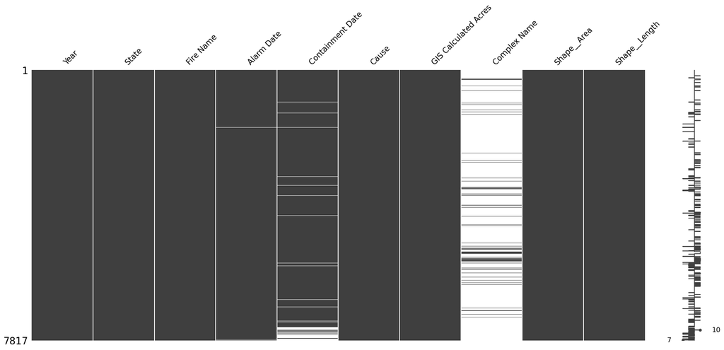

```python
#visualize our missing data
msno.matrix(fires)
```

```python
#look at data types and ensure all columns are the correct data type that we need
fires.dtypes
```

```
Year                      int64
State                    object
Fire Name                object
Alarm Date               object
Containment Date         object
Cause                   float64
GIS Calculated Acres    float64
Complex Name             object
Shape__Area             float64
Shape__Length           float64
dtype: object
```

#### Converting Data Types and Adding Columns

```python
#convert Start from object to float64 using datetime
# Convert the 'date' column to datetime
fires['Alarm Date'] = pd.to_datetime(fires['Alarm Date'])
fires['Containment Date'] = pd.to_datetime(fires['Containment Date'])


#convert the 'Cause' column from float to object
fires['Cause'] = fires['Cause'].astype('object')

# Display the DataFrame with formatted dates
print(fires)
```

```
      Year State        Fire Name Alarm Date Containment Date Cause  \
0     2023    CA        WHITWORTH 2023-06-17       2023-06-17   5.0
1     2023    CA           KAISER 2023-06-02       2023-06-02   5.0
2     2023    CA          JACKSON 2023-07-01       2023-07-02   2.0
3     2023    CA           CARBON 2023-07-11       2023-07-11   9.0
4     2023    CA          LIBERTY 2023-07-11       2023-07-12  14.0
...    ...   ...              ...        ...              ...   ...
7812  2000    CA        PT BONITA 2000-10-22       2000-11-01   8.0
7813  2000    CA          CONIFER 2000-01-01       2000-01-20  18.0
7814  2000    CA            HAPPY 2000-07-22       2000-08-05   5.0
7815  2000    CA        CALABASAS 2000-06-11       2000-06-12  14.0
7816  2000    NV  TURTLE MOUNTAIN        NaT              NaT  14.0

      GIS Calculated Acres  Complex Name   Shape__Area  Shape__Length
0                 5.729125           NaN  4.140784e+04    1247.166034
1                13.602380           NaN  9.345588e+04    1285.514550
2                27.814460           NaN  1.830285e+05    2697.587429
3                58.760230           NaN  3.882220e+05    2548.738779
4                70.979000           NaN  4.664560e+05    5106.936526
...                    ...           ...           ...            ...
7812             11.038910           NaN  7.171864e+04    1224.646739
7813              4.834736           NaN  3.029859e+04     723.541643
7814           4907.750000           NaN  3.045575e+07   32254.675480
7815           1024.243000           NaN  6.072928e+06   12488.245860
7816           1075.476000  RENO COMPLEX  7.447800e+06   15250.545150

[7817 rows x 10 columns]
```

```python
#double check that the data type officially updated
fires.dtypes
```

```
Year                             int64
State                           object
Fire Name                       object
Alarm Date              datetime64[ns]
Containment Date        datetime64[ns]
Cause                           object
GIS Calculated Acres           float64
Complex Name                    object
Shape__Area                    float64
Shape__Length                  float64
dtype: object
```

```python
# fill in Month column based on both alarm date and containment date columns
#some fires have containment date, but not alarm date so this solves that issue
fires['Month'] = fires['Alarm Date'].dt.month.combine_first(fires['Containment Date'].dt.month)
fires
```

|  | Year | State | Fire Name | Alarm Date | Containment Date | Cause | GIS Calculated Acres | Complex Name | Shape__Area | Shape__Length | Month |
| --- | --- | --- | --- | --- | --- | --- | --- | --- | --- | --- | --- |
| 0 | 2023 | CA | WHITWORTH | 2023-06-17 | 2023-06-17 | 5.0 | 5.729125 | NaN | 4.140784e+04 | 1247.166034 | 6.0 |
| 1 | 2023 | CA | KAISER | 2023-06-02 | 2023-06-02 | 5.0 | 13.602380 | NaN | 9.345588e+04 | 1285.514550 | 6.0 |
| 2 | 2023 | CA | JACKSON | 2023-07-01 | 2023-07-02 | 2.0 | 27.814460 | NaN | 1.830285e+05 | 2697.587429 | 7.0 |
| 3 | 2023 | CA | CARBON | 2023-07-11 | 2023-07-11 | 9.0 | 58.760230 | NaN | 3.882220e+05 | 2548.738779 | 7.0 |
| 4 | 2023 | CA | LIBERTY | 2023-07-11 | 2023-07-12 | 14.0 | 70.979000 | NaN | 4.664560e+05 | 5106.936526 | 7.0 |
| ... | ... | ... | ... | ... | ... | ... | ... | ... | ... | ... | ... |
| 7812 | 2000 | CA | PT BONITA | 2000-10-22 | 2000-11-01 | 8.0 | 11.038910 | NaN | 7.171864e+04 | 1224.646739 | 10.0 |
| 7813 | 2000 | CA | CONIFER | 2000-01-01 | 2000-01-20 | 18.0 | 4.834736 | NaN | 3.029859e+04 | 723.541643 | 1.0 |
| 7814 | 2000 | CA | HAPPY | 2000-07-22 | 2000-08-05 | 5.0 | 4907.750000 | NaN | 3.045575e+07 | 32254.675480 | 7.0 |
| 7815 | 2000 | CA | CALABASAS | 2000-06-11 | 2000-06-12 | 14.0 | 1024.243000 | NaN | 6.072928e+06 | 12488.245860 | 6.0 |
| 7816 | 2000 | NV | TURTLE MOUNTAIN | NaT | NaT | 14.0 | 1075.476000 | RENO COMPLEX | 7.447800e+06 | 15250.545150 | NaN |

7817 rows × 11 columns

```python
# find the fires where Month is null
fires[fires['Month'].isna()].count()
```

```
Year                    45
State                   45
Fire Name               45
Alarm Date               0
Containment Date         0
Cause                   44
GIS Calculated Acres    45
Complex Name             3
Shape__Area             45
Shape__Length           45
Month                    0
dtype: int64
```

```python
#look at data where Month is NaN
fires[fires['Month'].isna()]
```

|  | Year | State | Fire Name | Alarm Date | Containment Date | Cause | GIS Calculated Acres | Complex Name | Shape__Area | Shape__Length | Month |
| --- | --- | --- | --- | --- | --- | --- | --- | --- | --- | --- | --- |
| 1561 | 2019 | CA | YORK | NaT | NaT | 14.0 | 160.912400 | NaN | 9.918299e+05 | 6794.079424 | NaN |
| 1655 | 2019 | CA | BORDER | NaT | NaT | 14.0 | 11.514280 | NaN | 7.880199e+04 | 1411.711457 | NaN |
| 1659 | 2019 | CA | KELTY | NaT | NaT | 14.0 | 4.613461 | NaN | 2.992416e+04 | 950.652857 | NaN |
| 1661 | 2019 | CA | TAMARACK | NaT | NaT | 14.0 | 67.217480 | NaN | 4.446035e+05 | 3070.190855 | NaN |
| 1784 | 2019 | CA | STAR | NaT | NaT | 14.0 | 66.587180 | NaN | 4.051741e+05 | 4777.042672 | NaN |
| 2057 | 2018 | CA | SKYLINE LRA | NaT | NaT | 14.0 | 281.622500 | NaN | 1.656090e+06 | 7178.546611 | NaN |
| 3137 | 2016 | CA | SCOTT | NaT | NaT | 14.0 | 86.696410 | NaN | 5.739299e+05 | 4668.884698 | NaN |
| 3140 | 2016 | CA | BELL | NaT | NaT | 14.0 | 45.819710 | NaN | 3.034013e+05 | 2927.881007 | NaN |
| 3470 | 2015 | CA | HOTEL | NaT | NaT | 1.0 | 29.412400 | NaN | 1.860156e+05 | 2296.812710 | NaN |
| 3488 | 2015 | CA | ROADRUNNER | NaT | NaT | 14.0 | 0.023172 | NaN | 1.374414e+02 | 46.983296 | NaN |
| 3489 | 2015 | CA | DEERVALE | NaT | NaT | 14.0 | 0.602869 | NaN | 3.570238e+03 | 255.103003 | NaN |
| 3490 | 2015 | CA | TOPANGA | NaT | NaT | 11.0 | 0.251648 | NaN | 1.496210e+03 | 137.120150 | NaN |
| 3491 | 2015 | CA | OAKMONT | NaT | NaT | 14.0 | 0.251639 | NaN | 1.494488e+03 | 137.041209 | NaN |
| 4135 | 2012 | CA | BUCKMAN 2 | NaT | NaT | 14.0 | 6.940402 | NaN | 3.984297e+04 | 1089.122193 | NaN |
| 5560 | 2008 | CA | AVENAL | NaT | NaT | 7.0 | 945.332500 | NaN | 5.852305e+06 | 16335.501090 | NaN |
| 5561 | 2008 | CA | MADSEN | NaT | NaT | 2.0 | 27.598330 | NaN | 1.747153e+05 | 2201.688881 | NaN |
| 5562 | 2008 | CA | GATOS | NaT | NaT | 7.0 | 330.683400 | NaN | 2.060794e+06 | 13080.128440 | NaN |
| 5563 | 2008 | CA | AVOCADO | NaT | NaT | 11.0 | 1175.196000 | NaN | 7.429893e+06 | 15405.037050 | NaN |
| 5564 | 2008 | CA | AUBERRY | NaT | NaT | 2.0 | 9.355068 | NaN | 5.941969e+04 | 1646.682396 | NaN |
| 5565 | 2008 | CA | RUSTY | NaT | NaT | 7.0 | 100.440800 | NaN | 6.378367e+05 | 4784.834762 | NaN |
| 5567 | 2008 | CA | H. RANCH | NaT | NaT | 1.0 | 100.443200 | MENDOCINO LIGHTNING COMPLEX | 6.932004e+05 | 3375.189179 | NaN |
| 5603 | 2008 | CA | COLEMAN 1 | NaT | NaT | 14.0 | 155.260200 | NaN | 1.084790e+06 | 4968.611848 | NaN |
| 6579 | 2004 | CA | CASTLE | NaT | NaT | 14.0 | 570.108900 | NaN | 3.570966e+06 | 12121.223890 | NaN |
| 6580 | 2004 | CA | STAGEL | NaT | NaT | 14.0 | 313.373400 | NaN | 1.935718e+06 | 6727.749632 | NaN |
| 6616 | 2004 | NV | GATES COMPLEX | NaT | NaT | NaN | 8905.459000 | GATES COMPLEX | 5.917579e+07 | 47873.717700 | NaN |
| 6893 | 2003 | CA |  | NaT | NaT | 14.0 | 2713.938000 | NaN | 1.577259e+07 | 16731.294530 | NaN |
| 7601 | 2001 | CA | ALISOS | NaT | NaT | 10.0 | 164.773600 | NaN | 9.907713e+05 | 4714.974297 | NaN |
| 7609 | 2001 | CA | TRAFALGAR | NaT | NaT | 8.0 | 0.844819 | NaN | 4.920453e+03 | 404.156273 | NaN |
| 7635 | 2001 | CA | HOOVER | NaT | NaT | 1.0 | 7230.624000 | NaN | 4.677170e+07 | 136952.977100 | NaN |
| 7692 | 2000 | CA | CORRAL | NaT | NaT | 14.0 | 105.141000 | NaN | 6.804459e+05 | 3751.110994 | NaN |
| 7716 | 2000 | CA | BEEROCK | NaT | NaT | 14.0 | 58.920020 | NaN | 3.525306e+05 | 3328.303644 | NaN |
| 7765 | 2000 | CA | REDFERN | NaT | NaT | 14.0 | 75.283240 | NaN | 4.783830e+05 | 5096.525765 | NaN |
| 7766 | 2000 | CA | CASA | NaT | NaT | 14.0 | 164.318100 | NaN | 1.044280e+06 | 4217.448727 | NaN |
| 7767 | 2000 | CA | UTC | NaT | NaT | 14.0 | 254.511300 | NaN | 1.627188e+06 | 6202.165694 | NaN |
| 7768 | 2000 | CA | PATTERSON PASS #2 | NaT | NaT | 14.0 | 237.572200 | NaN | 1.539022e+06 | 5505.895647 | NaN |
| 7769 | 2000 | CA | SEREDA | NaT | NaT | 14.0 | 79.576420 | NaN | 5.180717e+05 | 3875.109171 | NaN |
| 7770 | 2000 | CA | HAYWARD ASSIST | NaT | NaT | 14.0 | 75.462360 | NaN | 4.879990e+05 | 2596.141720 | NaN |
| 7795 | 2000 | CA |  | NaT | NaT | 14.0 | 1044.769000 | NaN | 6.441534e+06 | 13604.184160 | NaN |
| 7796 | 2000 | CA |  | NaT | NaT | 14.0 | 301.647800 | NaN | 1.859276e+06 | 5699.126147 | NaN |
| 7797 | 2000 | CA |  | NaT | NaT | 14.0 | 658.354000 | NaN | 4.058167e+06 | 11252.473800 | NaN |
| 7798 | 2000 | CA |  | NaT | NaT | 14.0 | 162.369100 | NaN | 1.001834e+06 | 4809.044136 | NaN |
| 7799 | 2000 | CA |  | NaT | NaT | 13.0 | 1028.244000 | NaN | 6.340508e+06 | 13653.028400 | NaN |
| 7800 | 2000 | CA |  | NaT | NaT | 14.0 | 609.029900 | NaN | 3.748732e+06 | 8521.366582 | NaN |
| 7801 | 2000 | CA |  | NaT | NaT | 10.0 | 4.930998 | NaN | 3.045220e+04 | 1053.346616 | NaN |
| 7816 | 2000 | NV | TURTLE MOUNTAIN | NaT | NaT | 14.0 | 1075.476000 | RENO COMPLEX | 7.447800e+06 | 15250.545150 | NaN |

```python
fires[fires['Month'].isna()].sum()
```

```
Year                                                                90314
State                   CACACACACACACACACACACACACACACACACACACACACACACA...
Fire Name               YORKBORDERKELTYTAMARACKSTARSKYLINE LRASCOTTBEL...
Cause                                                               511.0
GIS Calculated Acres                                         29441.502205
Shape__Area                                              188587944.600947
Shape__Length                                               431480.755563
Month                                                                 0.0
dtype: object
```

#### There are 45 fires that do not have an Alarm Date or Containment date. We *could* delete these rows from the dataset, but the total acreage of them all is nearly 30,000, which seems significant enough that it could skew our data if we deleted them. For now, we will keep these data for the sake of later analyses.

```python
fires
```

|  | Year | State | Fire Name | Alarm Date | Containment Date | Cause | GIS Calculated Acres | Complex Name | Shape__Area | Shape__Length | Month |
| --- | --- | --- | --- | --- | --- | --- | --- | --- | --- | --- | --- |
| 0 | 2023 | CA | WHITWORTH | 2023-06-17 | 2023-06-17 | 5.0 | 5.729125 | NaN | 4.140784e+04 | 1247.166034 | 6.0 |
| 1 | 2023 | CA | KAISER | 2023-06-02 | 2023-06-02 | 5.0 | 13.602380 | NaN | 9.345588e+04 | 1285.514550 | 6.0 |
| 2 | 2023 | CA | JACKSON | 2023-07-01 | 2023-07-02 | 2.0 | 27.814460 | NaN | 1.830285e+05 | 2697.587429 | 7.0 |
| 3 | 2023 | CA | CARBON | 2023-07-11 | 2023-07-11 | 9.0 | 58.760230 | NaN | 3.882220e+05 | 2548.738779 | 7.0 |
| 4 | 2023 | CA | LIBERTY | 2023-07-11 | 2023-07-12 | 14.0 | 70.979000 | NaN | 4.664560e+05 | 5106.936526 | 7.0 |
| ... | ... | ... | ... | ... | ... | ... | ... | ... | ... | ... | ... |
| 7812 | 2000 | CA | PT BONITA | 2000-10-22 | 2000-11-01 | 8.0 | 11.038910 | NaN | 7.171864e+04 | 1224.646739 | 10.0 |
| 7813 | 2000 | CA | CONIFER | 2000-01-01 | 2000-01-20 | 18.0 | 4.834736 | NaN | 3.029859e+04 | 723.541643 | 1.0 |
| 7814 | 2000 | CA | HAPPY | 2000-07-22 | 2000-08-05 | 5.0 | 4907.750000 | NaN | 3.045575e+07 | 32254.675480 | 7.0 |
| 7815 | 2000 | CA | CALABASAS | 2000-06-11 | 2000-06-12 | 14.0 | 1024.243000 | NaN | 6.072928e+06 | 12488.245860 | 6.0 |
| 7816 | 2000 | NV | TURTLE MOUNTAIN | NaT | NaT | 14.0 | 1075.476000 | RENO COMPLEX | 7.447800e+06 | 15250.545150 | NaN |

7817 rows × 11 columns

```python
#one option to replace all the numbers with words, but this is long and tedious

#fires.loc[fires['Month'] == 1.0, 'Month'] = 'January'
#fires.loc[fires['Month'] == 2.0, 'Month'] = 'February'
#fires.loc[fires['Month'] == 3.0, 'Month'] = 'March'
#fires.loc[fires['Month'] == 4.0, 'Month'] = 'April'
#fires.loc[fires['Month'] == 5.0, 'Month'] = 'May'
#fires.loc[fires['Month'] == 6.0, 'Month'] = 'June'
#fires.loc[fires['Month'] == 7.0, 'Month'] = 'July'
#fires.loc[fires['Month'] == 8.0, 'Month'] = 'August'
#fires.loc[fires['Month'] == 9.0, 'Month'] = 'September'
#fires.loc[fires['Month'] == 10.0, 'Month'] = 'October'
#fires.loc[fires['Month'] == 11.0, 'Month'] = 'November'
#fires.loc[fires['Month'] == 12.0, 'Month'] = 'December'

#fires
```

```python
#a better, automated option

# Convert Month to string
fires['Month'] = fires['Month'].astype('string')

#create a dictionary of the month numbers and words
month_words_dict = {
    '1.0': 'January',
    '2.0': 'February',
    '3.0': 'March',
    '4.0': 'April',
    '5.0': 'May',
    '6.0': 'June',
    '7.0': 'July',
    '8.0': 'August',
    '9.0': 'September',
    '10.0': 'October',
    '11.0': 'November',
    '12.0': 'December'
}

# Replace numeric month values with their names
fires['Month'] = fires['Month'].replace(month_words_dict)

fires
```

|  | Year | State | Fire Name | Alarm Date | Containment Date | Cause | GIS Calculated Acres | Complex Name | Shape__Area | Shape__Length | Month |
| --- | --- | --- | --- | --- | --- | --- | --- | --- | --- | --- | --- |
| 0 | 2023 | CA | WHITWORTH | 2023-06-17 | 2023-06-17 | 5.0 | 5.729125 | NaN | 4.140784e+04 | 1247.166034 | June |
| 1 | 2023 | CA | KAISER | 2023-06-02 | 2023-06-02 | 5.0 | 13.602380 | NaN | 9.345588e+04 | 1285.514550 | June |
| 2 | 2023 | CA | JACKSON | 2023-07-01 | 2023-07-02 | 2.0 | 27.814460 | NaN | 1.830285e+05 | 2697.587429 | July |
| 3 | 2023 | CA | CARBON | 2023-07-11 | 2023-07-11 | 9.0 | 58.760230 | NaN | 3.882220e+05 | 2548.738779 | July |
| 4 | 2023 | CA | LIBERTY | 2023-07-11 | 2023-07-12 | 14.0 | 70.979000 | NaN | 4.664560e+05 | 5106.936526 | July |
| ... | ... | ... | ... | ... | ... | ... | ... | ... | ... | ... | ... |
| 7812 | 2000 | CA | PT BONITA | 2000-10-22 | 2000-11-01 | 8.0 | 11.038910 | NaN | 7.171864e+04 | 1224.646739 | October |
| 7813 | 2000 | CA | CONIFER | 2000-01-01 | 2000-01-20 | 18.0 | 4.834736 | NaN | 3.029859e+04 | 723.541643 | January |
| 7814 | 2000 | CA | HAPPY | 2000-07-22 | 2000-08-05 | 5.0 | 4907.750000 | NaN | 3.045575e+07 | 32254.675480 | July |
| 7815 | 2000 | CA | CALABASAS | 2000-06-11 | 2000-06-12 | 14.0 | 1024.243000 | NaN | 6.072928e+06 | 12488.245860 | June |
| 7816 | 2000 | NV | TURTLE MOUNTAIN | NaT | NaT | 14.0 | 1075.476000 | RENO COMPLEX | 7.447800e+06 | 15250.545150 | <NA> |

7817 rows × 11 columns

## Part 2: Data Visualization

```python
fires
```

|  | Year | State | Fire Name | Alarm Date | Containment Date | Cause | GIS Calculated Acres | Complex Name | Shape__Area | Shape__Length | Month |
| --- | --- | --- | --- | --- | --- | --- | --- | --- | --- | --- | --- |
| 0 | 2023 | CA | WHITWORTH | 2023-06-17 | 2023-06-17 | 5.0 | 5.729125 | NaN | 4.140784e+04 | 1247.166034 | June |
| 1 | 2023 | CA | KAISER | 2023-06-02 | 2023-06-02 | 5.0 | 13.602380 | NaN | 9.345588e+04 | 1285.514550 | June |
| 2 | 2023 | CA | JACKSON | 2023-07-01 | 2023-07-02 | 2.0 | 27.814460 | NaN | 1.830285e+05 | 2697.587429 | July |
| 3 | 2023 | CA | CARBON | 2023-07-11 | 2023-07-11 | 9.0 | 58.760230 | NaN | 3.882220e+05 | 2548.738779 | July |
| 4 | 2023 | CA | LIBERTY | 2023-07-11 | 2023-07-12 | 14.0 | 70.979000 | NaN | 4.664560e+05 | 5106.936526 | July |
| ... | ... | ... | ... | ... | ... | ... | ... | ... | ... | ... | ... |
| 7812 | 2000 | CA | PT BONITA | 2000-10-22 | 2000-11-01 | 8.0 | 11.038910 | NaN | 7.171864e+04 | 1224.646739 | October |
| 7813 | 2000 | CA | CONIFER | 2000-01-01 | 2000-01-20 | 18.0 | 4.834736 | NaN | 3.029859e+04 | 723.541643 | January |
| 7814 | 2000 | CA | HAPPY | 2000-07-22 | 2000-08-05 | 5.0 | 4907.750000 | NaN | 3.045575e+07 | 32254.675480 | July |
| 7815 | 2000 | CA | CALABASAS | 2000-06-11 | 2000-06-12 | 14.0 | 1024.243000 | NaN | 6.072928e+06 | 12488.245860 | June |
| 7816 | 2000 | NV | TURTLE MOUNTAIN | NaT | NaT | 14.0 | 1075.476000 | RENO COMPLEX | 7.447800e+06 | 15250.545150 | <NA> |

7817 rows × 11 columns

```python
#find total number of wildfires that occured each year
total_counts_per_year = fires.groupby('Year').size().reset_index(name='Total_Count')

# Print the result
print(total_counts_per_year)
```

```
    Year  Total_Count
0   2000          181
1   2001          206
2   2002          243
3   2003          339
4   2004          277
5   2005          304
6   2006          314
7   2007          348
8   2008          439
9   2009          254
10  2010          207
11  2011          316
12  2012          352
13  2013          297
14  2014          236
15  2015          317
16  2016          361
17  2017          608
18  2018          416
19  2019          319
20  2020          505
21  2021          388
22  2022          306
23  2023          284
```

```
    Year  Total_Count
0   2000          181
1   2001          206
2   2002          243
3   2003          339
4   2004          277
5   2005          304
6   2006          314
7   2007          348
8   2008          439
9   2009          254
10  2010          207
11  2011          316
12  2012          352
13  2013          297
14  2014          236
15  2015          317
16  2016          361
17  2017          608
18  2018          416
19  2019          319
20  2020          505
21  2021          388
22  2022          306
23  2023          284
```

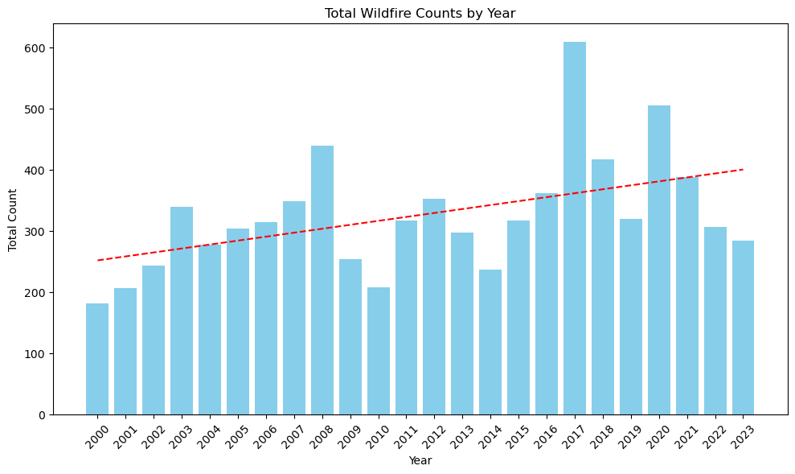

```python
# Find total count of wildfires that occured per year

# Group by 'Year' to find the total wildfire counts
total_counts_per_year = fires.groupby('Year').size().reset_index(name='Total_Count')

# Print the result to verify
print(total_counts_per_year)

plt.figure(figsize=(10, 6))

# Plotting the total counts per year
plt.bar(total_counts_per_year['Year'], total_counts_per_year['Total_Count'], color='skyblue', label='Total Wildfire Counts')

# Create chart
plt.title('Total Wildfire Counts by Year')
plt.xlabel('Year')
plt.ylabel('Total Count')
plt.xticks(total_counts_per_year['Year'], rotation=45)  # Rotate axis labels by 45 degrees
plt.tight_layout()

# Make trendline (1st degree polynomial)
z = np.polyfit(total_counts_per_year['Year'], total_counts_per_year['Total_Count'], 1)
p = np.poly1d(z)

# add trendline
plt.plot(total_counts_per_year['Year'], p(total_counts_per_year['Year']), color='red', linestyle='--', label='Trendline')

plt.show()
```

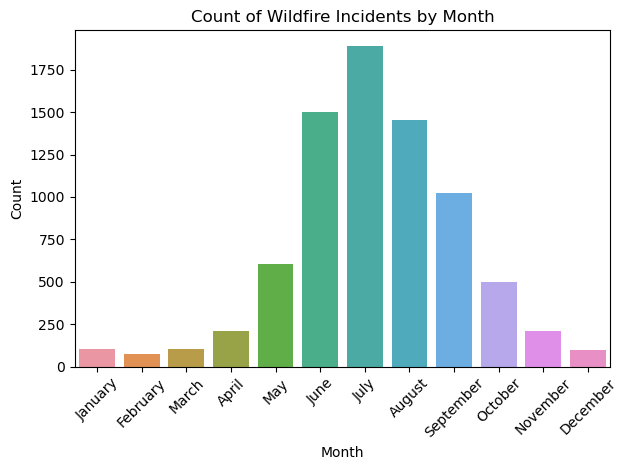

```python
# bar chart showing total number of fires for all years, most occuring month using seaborn
fires_by_month = sea.countplot(x='Month', data=fires, order=[
    'January', 'February', 'March', 'April', 'May',
    'June', 'July', 'August', 'September', 'October',
    'November', 'December'])
#rename axis labels
fires_by_month.set(xlabel='Month', ylabel='Count')
plt.title ("Count of Wildfire Incidents by Month")
plt.xticks(rotation=45)  # Rotate month labels
plt.tight_layout()  # Adjust layout
```

##### The most common month for wildfires to start is July.

```python
# finding the average number of acres burned each year
avg_acres_per_year = df.groupby('Year')['GIS Calculated Acres'].mean().reset_index()
# Set Pandas display option to avoid scientific notation
pd.set_option('display.float_format', '{:,.0f}'.format)
print(avg_acres_per_year)
```

```
    Year  GIS Calculated Acres
0   2000                 1,355
1   2001                 1,199
2   2002                 3,967
3   2003                 2,858
4   2004                   991
5   2005                   760
6   2006                 2,383
7   2007                 2,965
8   2008                 3,150
9   2009                 1,716
10  2010                   488
11  2011                   641
12  2012                 2,411
13  2013                 1,917
14  2014                 2,350
15  2015                 2,490
16  2016                 1,513
17  2017                 2,343
18  2018                 3,803
19  2019                   880
20  2020                 8,282
21  2021                 6,476
22  2022                 1,054
23  2023                 1,204
```

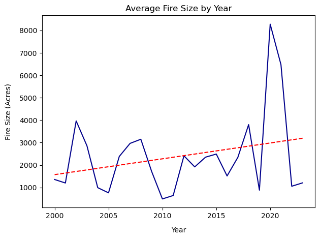

```python
# line plot between fire acreage and year: on average, are fires getting bigger each year?

# Fit a trendline (1st degree polynomial)
z = np.polyfit(avg_acres_per_year['Year'], avg_acres_per_year['GIS Calculated Acres'], 1)
p = np.poly1d(z)

# Create the line plot for average fire size
plt.plot(avg_acres_per_year['Year'], avg_acres_per_year['GIS Calculated Acres'], color='darkblue', label='Average Fire Size')

# Add trendline to the graph
plt.plot(avg_acres_per_year['Year'], p(avg_acres_per_year['Year']), color='red', linestyle='--', label='Trendline')

# Customize the plot
plt.title("Average Fire Size by Year")
plt.xlabel("Year", fontsize=10, labelpad=10)
plt.ylabel("Fire Size (Acres)", fontsize=10, labelpad=10)
plt.tight_layout()  # Adjust layout to prevent clipping

# Show the plot
plt.show()
```

```python
# finding the total number of acres burned each year
total_acres_per_year = df.groupby('Year')['GIS Calculated Acres'].sum().reset_index()
# Set Pandas display option to avoid scientific notation
pd.set_option('display.float_format', '{:,.0f}'.format)
print(total_acres_per_year)
```

```
    Year  GIS Calculated Acres
0   2000               245,246
1   2001               246,925
2   2002               963,898
3   2003               968,697
4   2004               274,639
5   2005               231,112
6   2006               748,170
7   2007             1,031,803
8   2008             1,382,710
9   2009               435,825
10  2010               101,056
11  2011               202,423
12  2012               848,692
13  2013               569,422
14  2014               554,656
15  2015               789,222
16  2016               546,250
17  2017             1,424,583
18  2018             1,581,917
19  2019               280,728
20  2020             4,182,336
21  2021             2,512,611
22  2022               322,528
23  2023               342,033
```

```
---------------------------------------------------------------------------
NameError                                 Traceback (most recent call last)
Cell In[36], line 15
     13 # Set y-axis to show values in thousands
     14 ax = plt.gca()
---> 15 formatter = ticker.ScalarFormatter()
     16 formatter.set_scientific(False)
     17 formatter.set_powerlimits((-3, 4))

NameError: name 'ticker' is not defined
```

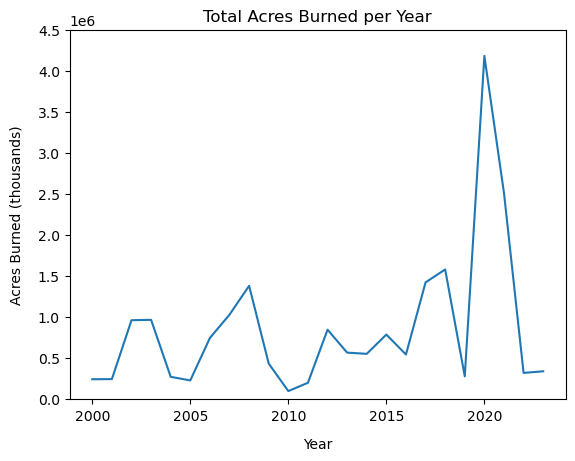

```python
# Find the total number of acres burned each year
total_acres_per_year = df.groupby('Year')['GIS Calculated Acres'].sum().reset_index()

# Create the line plot for total acres burned per year
sea.lineplot(data=total_acres_per_year, x='Year', y='GIS Calculated Acres')

# Set the title and axis labels
plt.title("Total Acres Burned per Year")
plt.xlabel("Year", fontsize=10, labelpad=10)
plt.ylabel("Acres Burned (thousands)", fontsize=10, labelpad=10)
plt.ylim(0, 4500000)

# Set y-axis to show values in thousands
ax = plt.gca()
formatter = ticker.ScalarFormatter()
formatter.set_scientific(False)
formatter.set_powerlimits((-3, 4))
ax.yaxis.set_major_formatter(formatter)

# Make trendline (1st degree polynomial)
z = np.polyfit(total_acres_per_year['Year'], total_acres_per_year['GIS Calculated Acres'], 1)
p = np.poly1d(z)

# Create line plot
plt.plot(total_acres_per_year['Year'], total_acres_per_year['GIS Calculated Acres'], color='darkblue', label='Average Fire Size')

# Add trendline
plt.plot(total_acres_per_year['Year'], p(total_acres_per_year['Year']), color='red', linestyle='--', label='Trendline')

# Show the plot
plt.show()
```

```python
#exploring 2020-specific data to see the largest acres of fires
fires_2020 = fires[fires['Year'] == 2020]

# Sort the DataFrame by 'GIS Calculated Acres' in descending order
sorted_fires_2020 = fires_2020.sort_values(by='GIS Calculated Acres', ascending=False)

# Select the top 3 wildfires
top_3_fires_2020 = sorted_fires_2020.head(3)

# Print the result
print(top_3_fires_2020[['Fire Name', 'GIS Calculated Acres']])
```

```
           Fire Name  GIS Calculated Acres
1271  AUGUST COMPLEX             1,032,700
1152     SCU COMPLEX               396,824
1219           CREEK               379,842
```

```python
# Comparing the largest fires by acreage for all years 2000-2023
# Find the maximum value of 'GIS Calculated Acres'
# Group by 'Year' and find the index of the maximum value in 'GIS Calculated Acres' for each group
idx = fires.groupby('Year')['GIS Calculated Acres'].idxmax()

#Find the rows corresponding to the largest fire for each year
largest_fires_per_year = fires.loc[idx]

print(largest_fires_per_year[['Year', 'Fire Name', 'GIS Calculated Acres']])
```

```
      Year       Fire Name  GIS Calculated Acres
7746  2000          MANTER                79,223
7513  2001            BLUE                34,219
7230  2002         BISCUIT               501,082
7165  2003           CEDAR               270,686
6670  2004          RUMSEY                38,763
6565  2005       WILDHORSE                63,771
6228  2006             DAY               161,816
5880  2007            ZACA               240,359
5468  2008         GALLERY               163,607
4919  2009         STATION               160,833
4721  2010            BULL                16,448
4503  2011        COMANCHE                25,939
4276  2012            RUSH               315,512
3982  2013             RIM               256,176
3612  2014      FRYING PAN               133,177
3362  2015           ROUGH               151,547
2983  2016       SOBERANES               132,104
2654  2017          THOMAS               281,791
2054  2018           RANCH               410,202
1507  2019         KINCADE                77,762
1271  2020  AUGUST COMPLEX             1,032,700
958   2021           DIXIE               963,405
503   2022        MOSQUITO                76,771
204   2023            YORK                93,078
```

```
---------------------------------------------------------------------------
NameError                                 Traceback (most recent call last)
Cell In[40], line 18
     16 # Set y-axis to show values in thousands
     17 ax = plt.gca()
---> 18 formatter = ticker.ScalarFormatter()
     19 formatter.set_scientific(False)
     20 formatter.set_powerlimits((-3, 4))

NameError: name 'ticker' is not defined
```

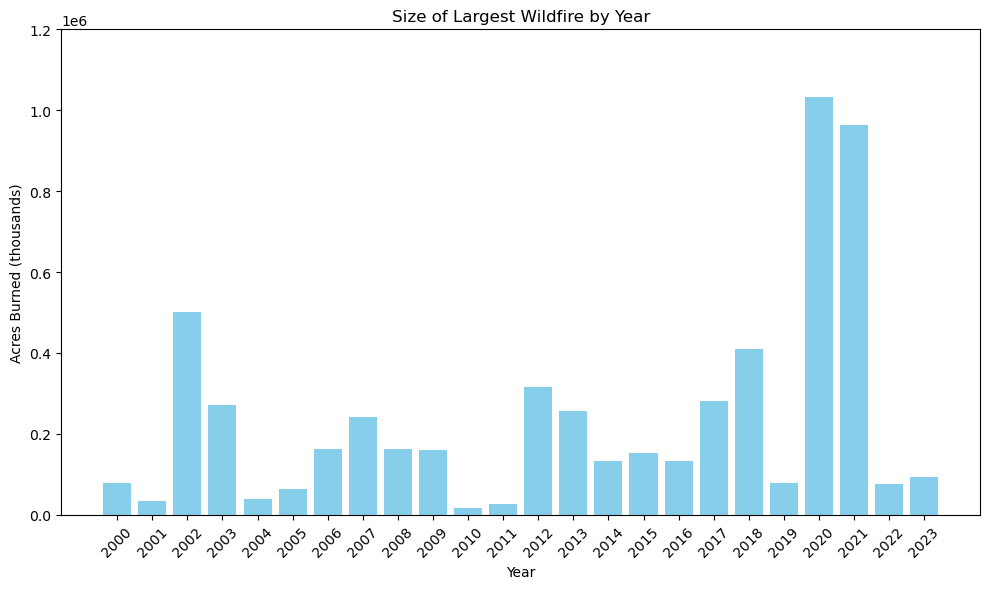

```python
#plot the largest fire each year for all years

plt.figure(figsize=(10, 6))

# Plotting the total counts per year
plt.bar(largest_fires_per_year['Year'], largest_fires_per_year['GIS Calculated Acres'], color='skyblue', label='Total Wildfire Counts')

# Create chart
plt.title('Size of Largest Wildfire by Year')
plt.xlabel('Year')
plt.ylabel('Acres Burned (thousands)')
plt.xticks(total_counts_per_year['Year'], rotation=45)  # Rotate axis labels by 45 degrees
plt.tight_layout()
plt.ylim(0, 1200000) #set range for y-axis

# Set y-axis to show values in thousands
ax = plt.gca()
formatter = ticker.ScalarFormatter()
formatter.set_scientific(False)
formatter.set_powerlimits((-3, 4))
ax.yaxis.set_major_formatter(formatter)
```

```python
#how many total incidents occur each year
yearly_counts = df.groupby('Year').size()
yearly_counts
```

```
Year
2000    181
2001    206
2002    243
2003    339
2004    277
2005    304
2006    314
2007    348
2008    439
2009    254
2010    207
2011    316
2012    352
2013    297
2014    236
2015    317
2016    361
2017    608
2018    416
2019    319
2020    505
2021    388
2022    306
2023    284
dtype: int64
```

```python
#plot the total count of wildfires occuring each year
# Create the line plot
ax = sea.lineplot(data=yearly_counts, x='Year', y='Total_Incidents')

# Set the title and axis labels
ax.set(title='Total Wildfires per Year', xlabel='Year', ylabel='Total Incidents')

# set up data and create polynomial for trendline
x = yearly_counts['Year']
y = yearly_counts['Total_Incidents']

z = np.polyfit(x, y, 1)  # Linear fit (degree 1)
p = np.poly1d(z)

# Generate x values for the trend line
x_fit = np.linspace(x.min(), x.max(), 100)
y_fit = p(x_fit)

# Plot the trend line
plt.plot(x_fit, y_fit, color='red', linestyle='--', label='Trend Line')

plt.show()
```

[output not shown]

[output cut: 15 more lines]

[output not shown]